# Market Risk

Iñaki Gangutia

2024-05-05

The purpose of this project is to show how a **Stochastic Geometric Brownian Movement Process** can be applied to the finance sector, specifically to model Market Risk. As an example we will use the data related to the Stands & Poor’s 500 (S&P 500), the most common, famous and reference index to follow the United States Economy.

We will use this type of process to model the evolution of a random system through time with a non constant random variable, being the growth of this variable exponential and with a non constant volatility as the moment value increases.

To start we will load some packages needed for our project, each one with a purpose.

```r
library(quantmod) # Import data
library(moments) # Extra descriptive statistics
library(ggplot2) # Plots
library(knitr) # Tables creation
library(kableExtra) # Tables creation
```

Now we will import our S&P 500 data from Yahoo as data provider.

```r
getSymbols("^GSPC",
           src = "yahoo",
           from = "2020-03-23", # New cycle start (post-COVID19)
           to = Sys.Date()) # Last record
```

In this part we will manipulate the obtained data selecting the .Close prices, converting them to logarithms and calculating the returns.

```r
prices <- GSPC$GSPC.Close

log_returns <- diff(log(prices))[-1]
```

Now we will get some needed historical parameters for the Euler method.

```r
S0 <- as.numeric(tail(prices, 1)) # Initial price
mu <- mean(log_returns) # Expected return (drift)
sigma <- sd(log_returns) # Expected volatility
```

As it follows, we will set the rest of parameters for the Euler method.

```r
dt <- 0.01 # Time step unit
T <- 252 # Horizon Time (one trading year)
n_sim <- 252 / 0.01 # n simulations
n_tra <- 4 # n trajectories
```

This function will allow us to calculate various simulations and trajectories in base of the previous parameters. It is important to mention, that this method is an approximate numerical solution of the Stochastic Differential Equation (SDE).

```r
GBM <- function(S0, mu, sigma, dt, n_sim, n_tra) {

  trajectories <- list() # Trajectories storage

  # Iterate to generate trajectories
  for (tra in 1:n_tra) {

    trajectory <- numeric(n_sim + 1) # Store current trajectory

    trajectory[1] <- S0 # Set initial price


    # Iterate to calculate price changes
    for (t in 1:n_sim) {

      # Euler Method
      Z <- rnorm(1, mean = 0, sd = 1) # Standard normal random variable

      delta_S <- mu * trajectory[t] * dt + sigma * trajectory[t] * sqrt(dt) * Z # Delta S

      trajectory[t + 1] <- trajectory[t] + delta_S # Next price
    }

    trajectories[[tra]] <- trajectory # Add current trajectory
  }
  return(trajectories)
}


simulations_trajectories <- GBM(S0, mu, sigma, dt, n_sim, n_tra)
```

Next we will create a data frame to use all the data obtained from the previous simulations and trajectories.

```r
trajectories_data <- data.frame(Time = numeric(),
                                Price = numeric())

for (t in 1:n_tra) {
  time <- seq(0, T, by = dt)
  price <- simulations_trajectories[[t]]
  trajectories_data <- rbind(trajectories_data, data.frame(Time = time, Price = price))
}
```

With the created data frame we will calculate some important descriptive statistics to understand better the characteristics of our results.

```r
mean <- mean(trajectories_data$Price)
range <- max(trajectories_data$Price) - min(trajectories_data$Price)
iqr <- IQR(trajectories_data$Price)

variance <- var(trajectories_data$Price)
deviation <- sd(trajectories_data$Price)

skewness <- skewness(trajectories_data$Price)
kurtosis <- kurtosis(trajectories_data$Price)


Descriptive_Statistics <- data.frame(Mean = mean,
                                     Range = range,
                                     Interquartile_Range = iqr,
                                     Variance = variance,
                                     Standard_Deviation = deviation,
                                     Skewness = skewness,
                                     Kurtosis = kurtosis
)
rownames(Descriptive_Statistics) <- "S&P 500"

kable(Descriptive_Statistics, format = "html") %>%
    kable_styling(full_width = TRUE)
```

|  | Mean | Range | Interquartile_Range | Variance | Standard_Deviation | Skewness | Kurtosis |
| --- | --- | --- | --- | --- | --- | --- | --- |
| S&P 500 | 5830.999 | 4444.908 | 1290.685 | 1055003 | 1027.133 | 1.053001 | 3.283033 |

Next step is to create a data plot to appreciate visually our different trajectories.

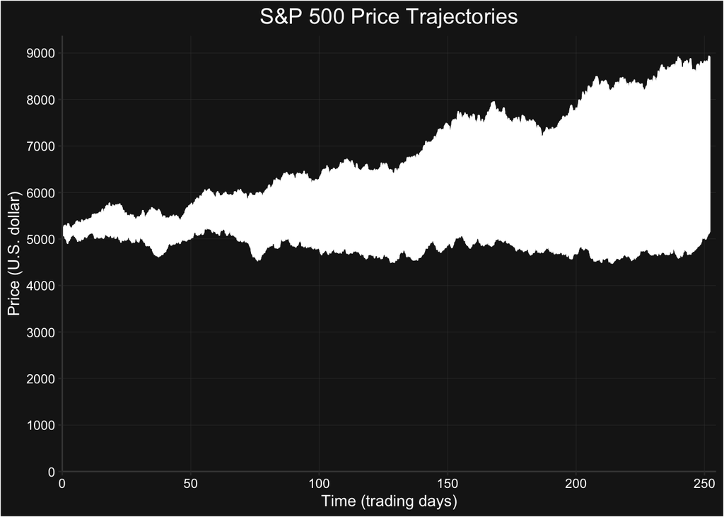

```r
gg_trajectories <- ggplot(data = trajectories_data, aes(x = Time, y = Price)) +
  geom_line(color="white") +
  ggtitle("S&P 500 Price Trajectories") +
  xlab("Time (trading days)") +
  ylab("Price (U.S. dollar)") +
  scale_y_continuous(limits = c(0, max(trajectories_data$Price) * 1.05),
                     expand = c(0, 0),
                     breaks = seq(0, max(trajectories_data$Price) * 1.05, by = 1000)) +
  scale_x_continuous(limits = c(min(trajectories_data$Time), max(trajectories_data$Time) * 1.01),
                     expand = c(0, 0)) +
  theme(
    plot.background = element_rect(fill = "#1A1A1A"),
    panel.background = element_rect(fill = "#1A1A1A"),
    panel.grid.major = element_line(color = "#444444", size = 0.1),
    panel.grid.minor = element_blank(),
    axis.line = element_line(color = "#444444"),
    plot.title = element_text(color = "white", size = 15, hjust = 0.5),
    axis.title = element_text(color = "white", size = 11),
    axis.text = element_text(color = "white", size = 9)
  )
show(gg_trajectories)
```

The Value at Risk (VaR) is a measure that will quantify the maximum risk of loss of our active over a given period of time and with a specific confidence level.

```r
VaR_func <- function(alpha) {

  var_vec <- numeric(length(simulations_trajectories)) # Storage vector

  # Iterate for each trajectory
  for (tra in 1:length(simulations_trajectories)) {
    trajectory <- simulations_trajectories[[tra]]
    var_vec[tra] <- quantile(trajectory, 1 - alpha)
  }

  var_aggregated <- quantile(var_vec, 1 - alpha) # Aggregated VaR

  return(var_aggregated)
}
```

The Conditional Value at Risk (CVaR) is a measure that provides an estimate of the expected value of losses in the worst case scenario. Being the weighted average of losses exceeding VaR for the confidence level given.

```r
CVaR_func <- function(alpha) {

  cvar_vec <- numeric(length(simulations_trajectories)) # Storage vector

  # Iterate for each trajectory
  for (tra in 1:length(simulations_trajectories)) {
    trajectory <- simulations_trajectories[[tra]]
    cvar_vec[tra] <- mean(trajectory[trajectory < VaR_func(alpha)])
  }

  es_aggreagted <- mean(cvar_vec) # Aggregated CVaR

  return(es_aggreagted)
}
```

The Maximum Drawdown is the peak-to-trough decline in our active over a given period of time.

```r
max_drawdown <- function() {

  max_vec <- numeric(length(simulations_trajectories)) # Storage vector

  for (tra in 1:length(simulations_trajectories)) {
    trajectory <- simulations_trajectories[[tra]]
    peak <- cummax(trajectory)
    max_vec[tra] <- max(peak - trajectory)
  }

  max_aggregated <- max(max_vec) # Maximum Drawdown

  return(max_aggregated)
}
```

Finally, we call the previous defined functions using an alpha of 0.05 or 5% and we create a data frame to show them together.

```r
alpha <- 0.05 # 95% confidence interval

Risk_Measurement <- data.frame(VaR = VaR_func(alpha),
                               CVaR = CVaR_func(alpha),
                               Maximum_Drawdown = max_drawdown()
)
rownames(Risk_Measurement) <- "S&P 500"

kable(Risk_Measurement, format = "html") %>%
    kable_styling(full_width = TRUE)
```

|  | VaR | CVaR | Maximum_Drawdown |
| --- | --- | --- | --- |
| S&P 500 | 8492.908 | 5790.688 | 971.6221 |